# Reproducible Research in R Workshop

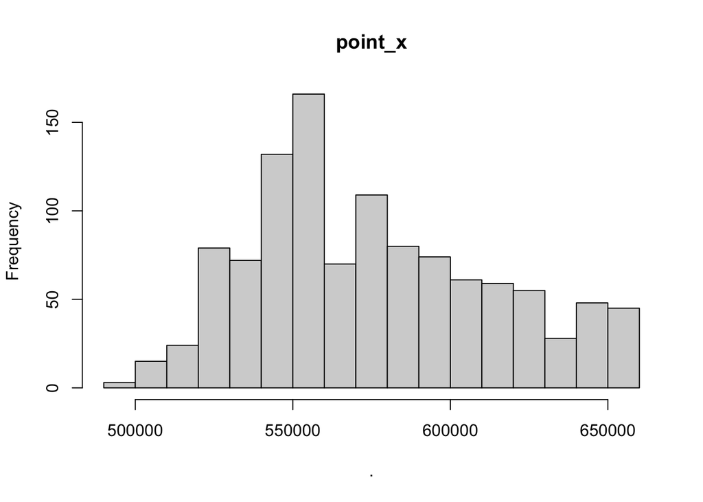

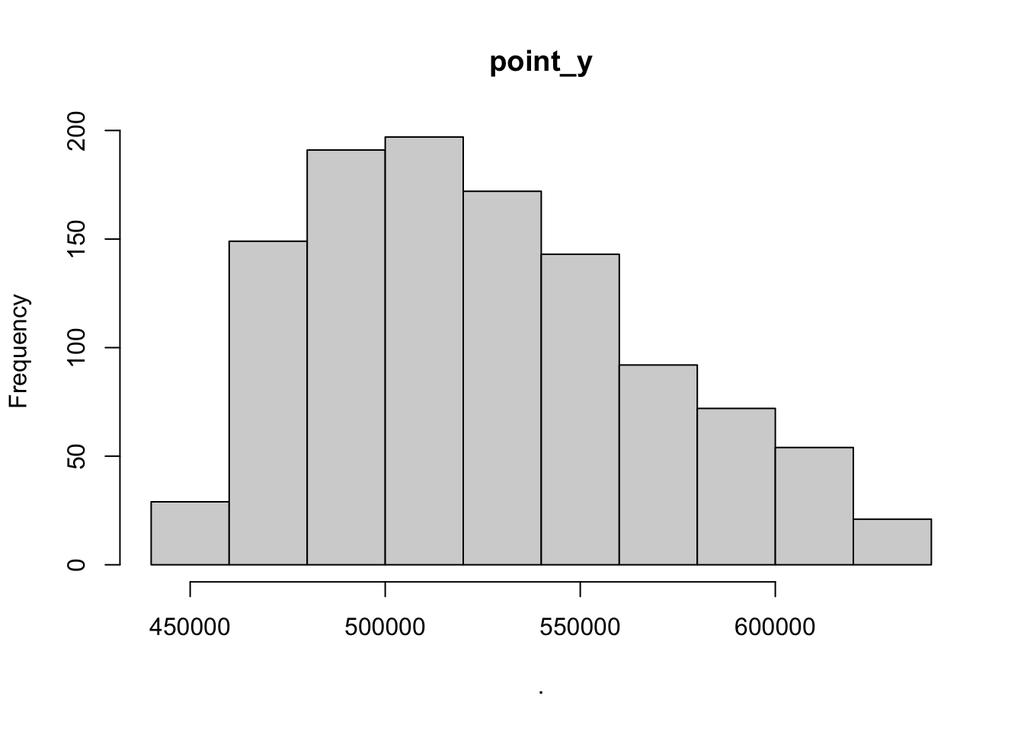

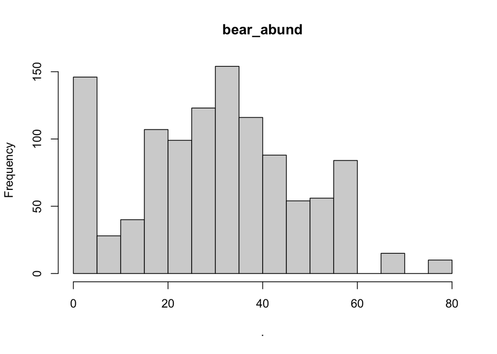

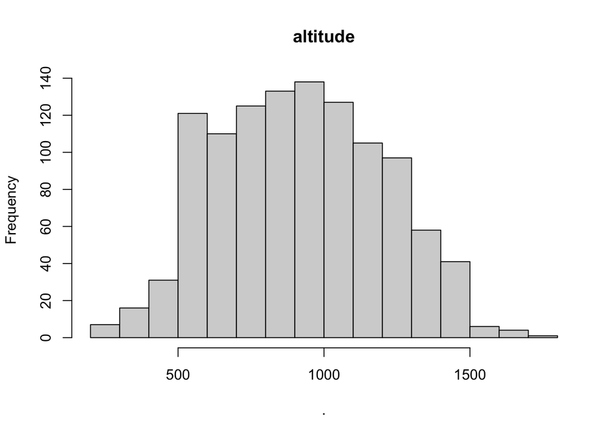

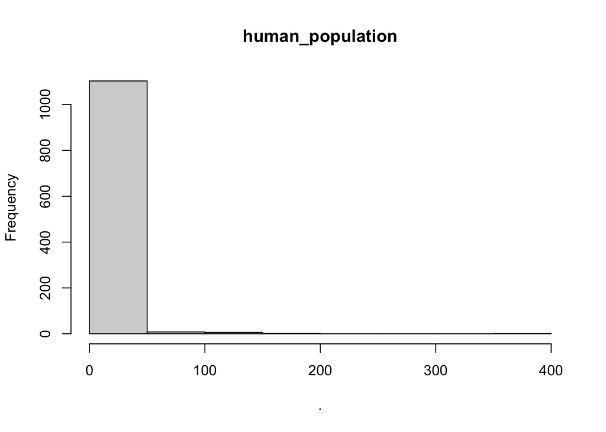

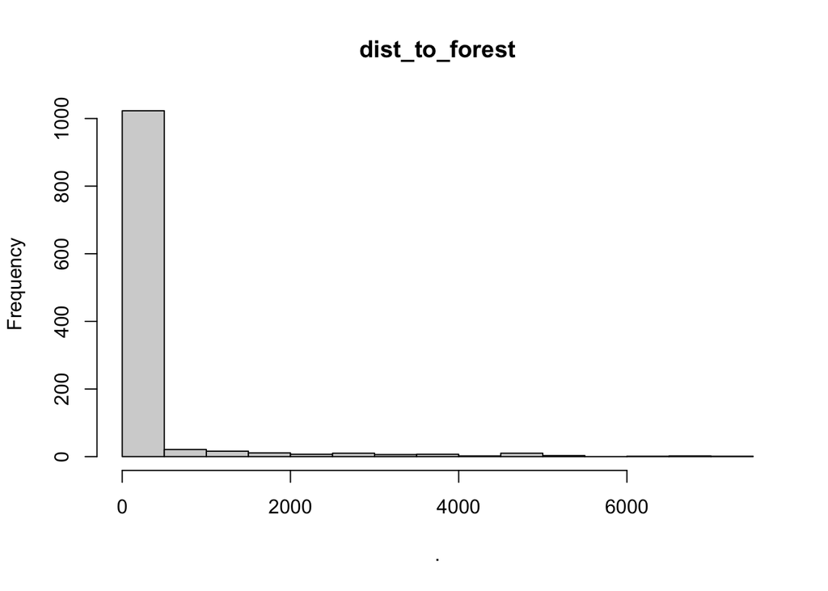

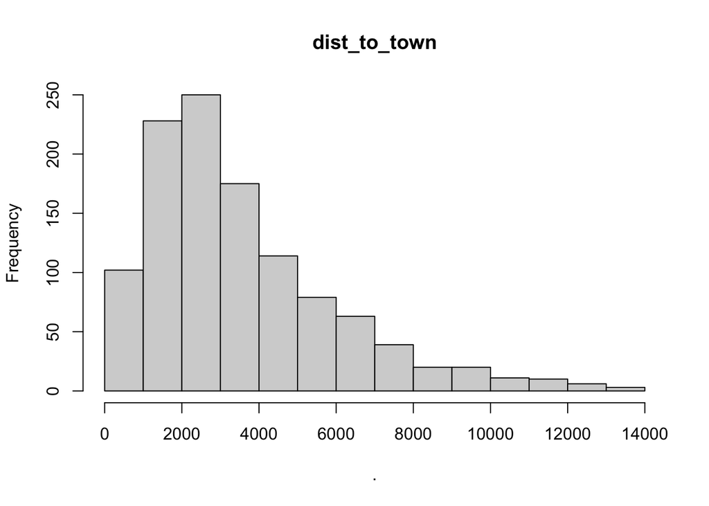

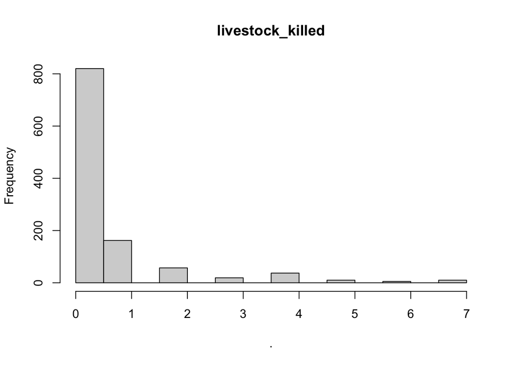

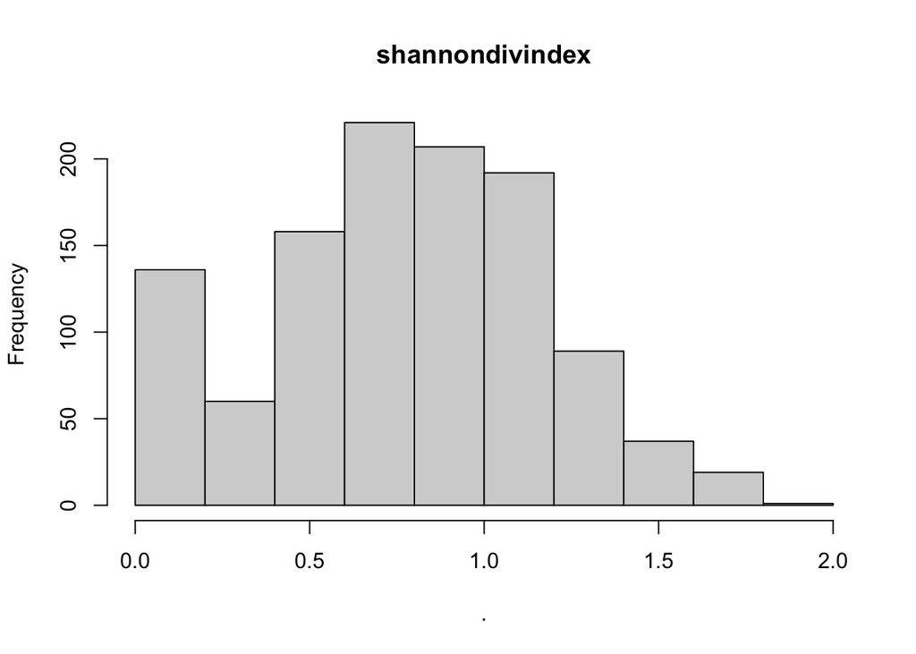

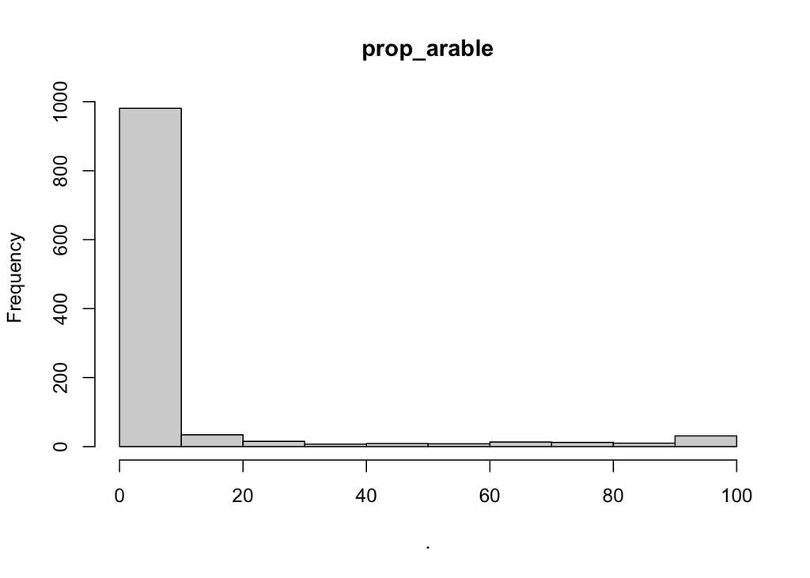

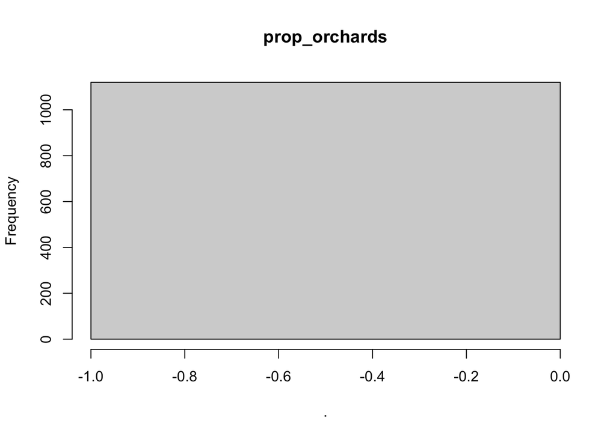

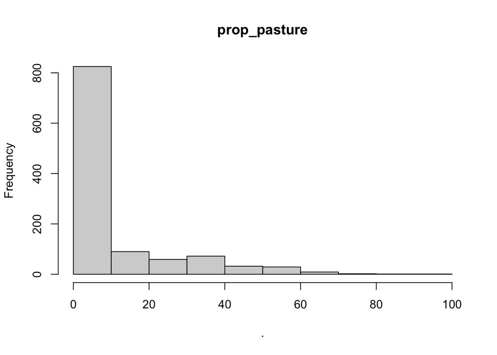

[8 more figures not shown]

[output not shown]

[output cut: 420 more lines]

[output not shown]

```r
# using purr to generate histograms of each expl. variable
bear_damage_tidy %>%

  # select only numeric variables
  select_if(is.numeric) %>%

  # use imap which will retain both the data (x) and the variable names (y)
  imap(~.x %>%

         # use the hist function on the data from previous pipe
        hist(.,

             # set the main title to y (each variable)
             main = .y))
```

Once we have looked at this we can drop any columns of data that aren’t usable or try to merge them with other variables if appropriate and check for multicolinearity between variables which is an assumption we need to meet for GLMs

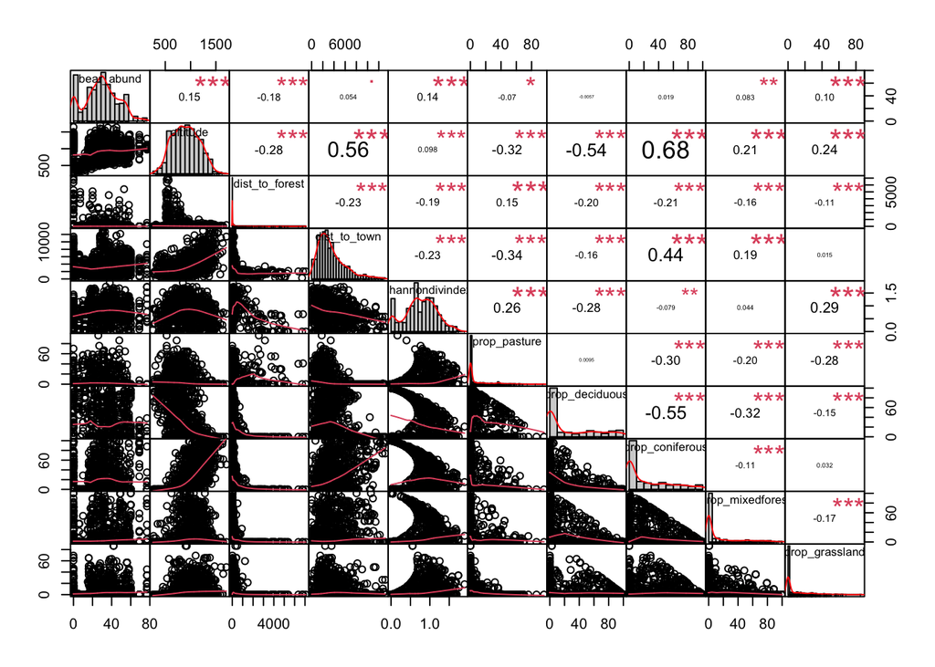

```r
bear_damage_tidy %>%

  # choose specific variables of interest
  select(bear_abund,
         altitude,
         dist_to_forest,
         dist_to_town,
         shannondivindex,
         prop_pasture,
         prop_deciduous,
         prop_coniferous,
         prop_mixedforest,
         prop_grassland) %>%

  chart.Correlation()
```

Above the diagonal of this matrix shows us Pearson’s R correlation coefficient for each pairwise combination of our chosen explanatory variables, the diagonal has the name of each variable with a histogram of the raw data, and below the diagonal is a correlation plot of each pairwise combination of variables.

We don’t want to include any variables that are highly correlated (absolute value r > 0.6) in the same model, so we will write some notes here about any that violate this or are close

altitude, prop_coniferous = 0.68  
altitude, dist_to_town = 0.56 prop_deciduous, prop_coniferous = -0.55 ( these are often inversely correlated in forested areas as they are the main two tree types so if there is a lot of one there’s less of the other, it’s not too high but if we know this ecological relationship exists we may want to be cautious about including them in the same model)

## Data formatting

Once we’ve explored both our explanatory and response variables, we may want to do some reformatting to our data. This can be for several reasons, if variables are correlated or lacking enough data to use one individually we may combine them if ecologically justified, etc.

Here we will create a new variable that combines all the forest cover data because we are interested in overall forest cover not the effect of specific forest types.

```r
# formatting data to combine variables
bear_damage_tidy <-  bear_damage_tidy %>%

  # add new column that groups all forest types
  mutate(prop_forest = rowSums(across(c(prop_coniferous,
                                      prop_deciduous,
                                      prop_mixedforest))))


# check new data
summary(bear_damage_tidy$prop_forest)
```

```
##    Min. 1st Qu.  Median    Mean 3rd Qu.    Max.
##    0.00   48.67   73.72   67.07   93.29  100.00
```

# Analysis

## Fit GLMs

Here we will create a candidate set of models that represent hypotheses about what variables may explain our chosen response and fit these to a glm with the appropriate distribution. As this is a mock analysis and not a course on human-wildlife conflict with bears in eastern Europe we won’t spend a ton of time justifying these models we will just use a few as examples.

> Note these are fit to a simple binomial distribution not a negative binomial distribution which is what we determined earlier would truly be the best-fit distribution

```r
# going to scale data first for ease of coding
bear_damage_tidy <- bear_damage_tidy %>%

  # use mutate to change all numeric variables to scaled
  mutate_if(is.numeric,
            scale)


#I've done 3 models for demonstration

# null model
bear_null <- glm(damage ~ 1,
                 data = bear_damage_tidy,
                 family = 'binomial')

# interaction between distance to forest and distance to town (close to both town and forest would have high prob of damage)
bear_distance_i <- glm(damage ~ dist_to_forest * dist_to_town,
                       data = bear_damage_tidy,
                 family = 'binomial')

# quick check that this model fit
summary(bear_distance_i)
```

```
##
## Call:
## glm(formula = damage ~ dist_to_forest * dist_to_town, family = "binomial",
##     data = bear_damage_tidy)
##
## Coefficients:
##                             Estimate Std. Error z value Pr(>|z|)
## (Intercept)                  -1.1042     0.1433  -7.705 1.31e-14 ***
## dist_to_forest                1.6345     0.4750   3.441  0.00058 ***
## dist_to_town                  0.2209     0.2179   1.014  0.31070
## dist_to_forest:dist_to_town   3.5312     0.7857   4.494 6.99e-06 ***
## ---
## Signif. codes:  0 '***' 0.001 '**' 0.01 '*' 0.05 '.' 0.1 ' ' 1
##
## (Dispersion parameter for binomial family taken to be 1)
##
##     Null deviance: 1044.92  on 1119  degrees of freedom
## Residual deviance:  960.37  on 1116  degrees of freedom
## AIC: 968.37
##
## Number of Fisher Scoring iterations: 7
```

```r
# analog distance model w/o interaction
bear_distance <- glm(damage ~ dist_to_forest +
                       dist_to_town,
                       data = bear_damage_tidy,
                 family = 'binomial')

# quick check that this model fit
summary(bear_distance)
```

```
##
## Call:
## glm(formula = damage ~ dist_to_forest + dist_to_town, family = "binomial",
##     data = bear_damage_tidy)
##
## Coefficients:
##                Estimate Std. Error z value Pr(>|z|)
## (Intercept)    -1.69548    0.09292 -18.247  < 2e-16 ***
## dist_to_forest -0.62093    0.18654  -3.329 0.000872 ***
## dist_to_town   -0.62435    0.10685  -5.843 5.12e-09 ***
## ---
## Signif. codes:  0 '***' 0.001 '**' 0.01 '*' 0.05 '.' 0.1 ' ' 1
##
## (Dispersion parameter for binomial family taken to be 1)
##
##     Null deviance: 1044.92  on 1119  degrees of freedom
## Residual deviance:  991.73  on 1117  degrees of freedom
## AIC: 997.73
##
## Number of Fisher Scoring iterations: 6
```

## Model selection

A common approach with GLMs is to use model selection and compare metrics like AIC to determine which set of explanatory variables best explains the observed data we collected.

We will do this using a function from the MuMIn package

```r
# model selection on candidate set of models
model.sel(bear_null,
          bear_distance,
          bear_distance_i)
```

```
## Model selection table
##                  (Int) dst_to_frs dst_to_twn dst_to_frs:dst_to_twn df   logLik
## bear_distance_i -1.104     1.6340     0.2209                 3.531  4 -480.183
## bear_distance   -1.695    -0.6209    -0.6243                        3 -495.865
## bear_null       -1.538                                              1 -522.462
##                   AICc delta weight
## bear_distance_i  968.4  0.00      1
## bear_distance    997.8 29.35      0
## bear_null       1046.9 78.53      0
## Models ranked by AICc(x)
```

Lowest AIC and highest model weight generally indicates the best fitting model. The MuMIn function will automatically sort your models in decreasing order of weight

Based on this our best-fit model is the one with our interaction term

## Check model assumptions

This section will vary depending on the response variable and other aspects of the data, models, etc.

For the best-fit model identified above we want to re-check assumption of independence with variance inflation factor (VIF), we also want to check for overdispersion, and any outliers

```r
# check assumptions for top model

vif(bear_distance_i)
```

```
## there are higher-order terms (interactions) in this model
## consider setting type = 'predictor'; see ?vif
```

```
##              dist_to_forest                dist_to_town
##                    4.770770                    3.652366
## dist_to_forest:dist_to_town
##                    7.012544
```

```
## there are higher-order terms (interactions) in this model
## consider setting type = 'predictor'; see ?vif
```

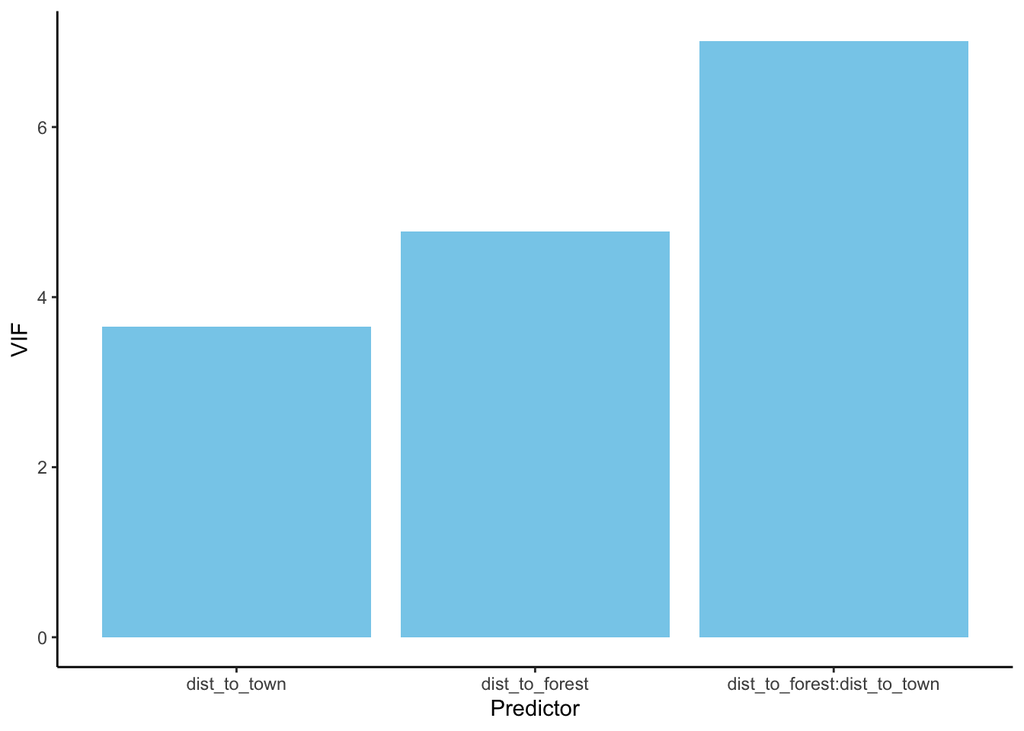

```r
# plot VIF
vif(bear_distance_i) %>%

  # Converts the named vector returned by vif() into a tidy tibble
  enframe(name = 'Predictor',
          value = 'VIF') %>%

  # plot with ggplot
  ggplot(aes(x = reorder(Predictor, VIF), # reorders from smallest VIF to largest
             y = VIF)) +

  # plot as bars
  geom_bar(stat = 'identity', fill = 'skyblue') +

  # add labels
  labs(x = 'Predictor',
       y = 'VIF') +

  # set theme
  theme_classic()
```

```r
# dispersion
summary(bear_distance_i)
```

```
##
## Call:
## glm(formula = damage ~ dist_to_forest * dist_to_town, family = "binomial",
##     data = bear_damage_tidy)
##
## Coefficients:
##                             Estimate Std. Error z value Pr(>|z|)
## (Intercept)                  -1.1042     0.1433  -7.705 1.31e-14 ***
## dist_to_forest                1.6345     0.4750   3.441  0.00058 ***
## dist_to_town                  0.2209     0.2179   1.014  0.31070
## dist_to_forest:dist_to_town   3.5312     0.7857   4.494 6.99e-06 ***
## ---
## Signif. codes:  0 '***' 0.001 '**' 0.01 '*' 0.05 '.' 0.1 ' ' 1
##
## (Dispersion parameter for binomial family taken to be 1)
##
##     Null deviance: 1044.92  on 1119  degrees of freedom
## Residual deviance:  960.37  on 1116  degrees of freedom
## AIC: 968.37
##
## Number of Fisher Scoring iterations: 7
```

```r
960.37/1116 # 0.86 slightly under dispersed but not a major issue for glm
```

```
## [1] 0.8605466
```

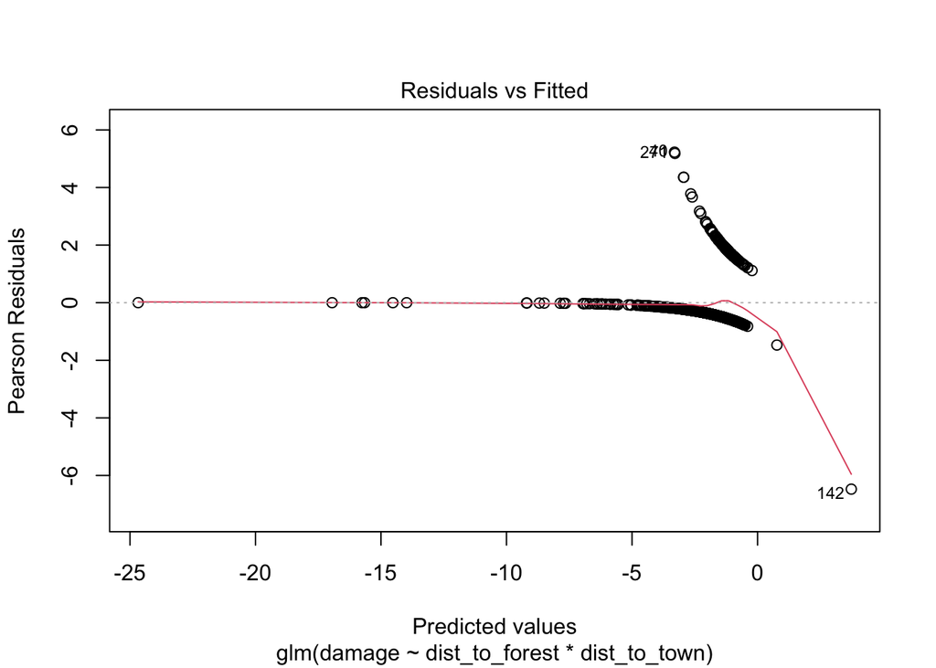

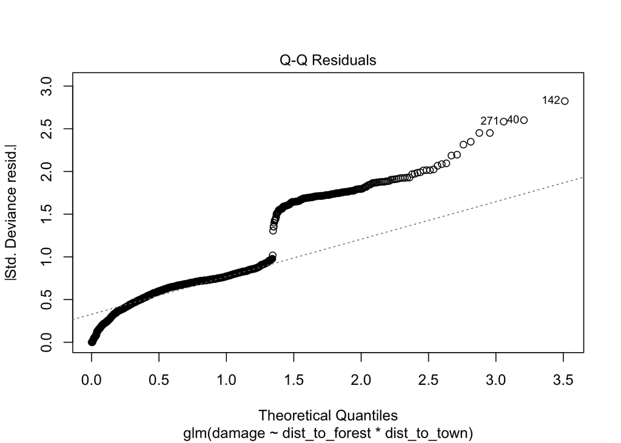

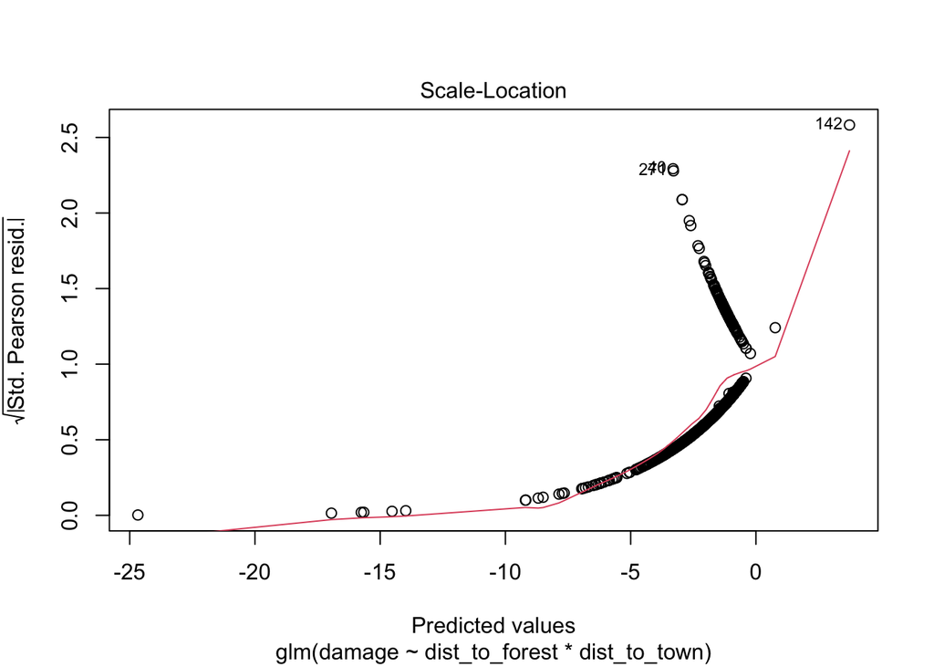

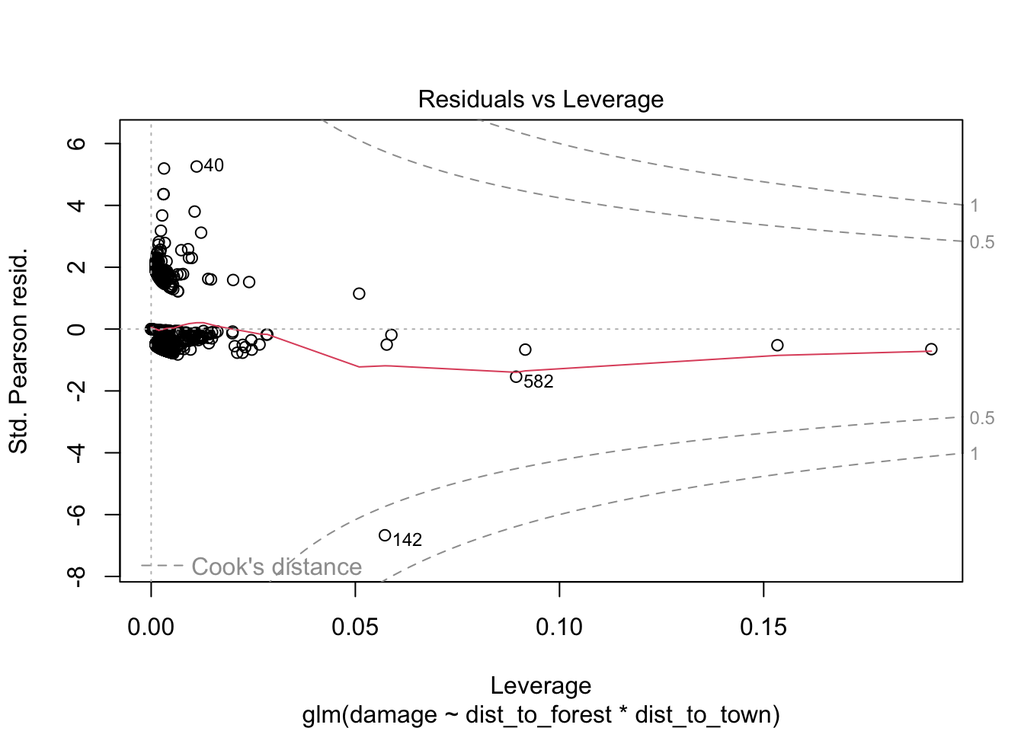

```r
# check for observations with high leverage
plot(bear_distance_i) # ignore first three
```

# Plot Results

There are several ways to plot results, for the purposes of this mock walk through we will plot odds ratios for the explanatory variables in our best-fit model. An odds ratio plot is a great way to show magnitude, confidence, and effect sizes for all your explanatory variables in one figure.

First we need to extract the odds ratios in a tidy format

```r
# create a new data frame with the odds ratios
model_odds <-

  # use the broom package to extract odds ratios into a tidy format
broom::tidy(bear_distance_i,
     exponentiate = TRUE,
     conf.int = TRUE)  %>%

  # remove intercept and interaction term as we don't need to plot
  filter(term  %in% c('dist_to_forest',
                  'dist_to_town'))
```

[output not shown]

```r
# check data
model_odds
```

```
## # A tibble: 2 × 7
##   term           estimate std.error statistic  p.value conf.low conf.high
##   <chr>             <dbl>     <dbl>     <dbl>    <dbl>    <dbl>     <dbl>
## 1 dist_to_forest     5.13     0.475      3.44 0.000580    2.08      13.2
## 2 dist_to_town       1.25     0.218      1.01 0.311       0.829      1.94
```

> Ignore warning for now as this is a mock analysis

Now we need to plot them in a visually pleasing and easily interpretable manner

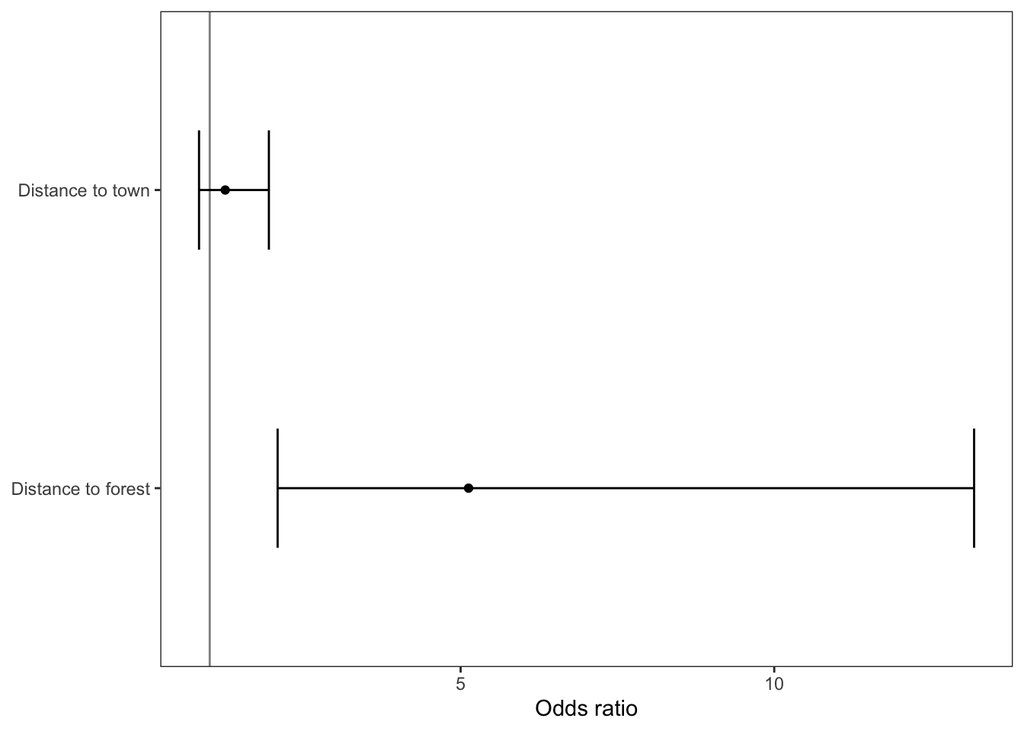

```r
# plot
# specify data and mapping asesthetics
ggplot(data = model_odds,
       aes(x = term,
           y = estimate)) +

  # add points for the odss
  geom_point() +

  # add errorbars for the confidence intervals
  geom_errorbar(aes(ymin = conf.low,
                    ymax = conf.high),
                linewidth = 0.5,
                width = 0.4) +

  geom_hline(yintercept = 1,
             alpha = 0.5) +

  # rename the x axis labels
  scale_x_discrete(labels = c('Distance to forest',
                              'Distance to town')) +

  # rename y axis title
  ylab('Odds ratio') +

  # flip x and y axis
      coord_flip() +

  # specify theme
  theme_bw() +

  # specify theme elements
  theme(panel.grid = element_blank(),
        axis.title.y = element_blank())
```